# 1. 변수 선정

## 변수 선정

아래와 같은 과정으로 여러 변수중에 유의미한 변수를 선택/추출한다.

- 분산분석(ANOVA)
- 카이제곱검정(Chi-Squared Test)
- 머신러닝 모델(LightGBM)
- SHAP

### 데이터 불러오기

전처리된 데이터를 불러온다.

```python
import pandas as pd
import numpy as np
import pickle, os
import warnings
warnings.filterwarnings('ignore')

df = pd.read_pickle('../Data/df_preprocessed.pkl')
```

변수 개수 확인:

```python
df.shape
```

[output not shown]

### 분산분석(ANOVA)

연속형 변수에 대해 분산분석을 적용한다.

```python
from sklearn.feature_selection import chi2, f_classif
from sklearn.feature_selection import SelectKBest
num_col = np.setdiff1d(df.select_dtypes('number').columns.values, ['id','loan_status'])
X, y = df[num_col], df['loan_status']

selector = SelectKBest(f_classif, k=50)
selector.fit(X,y)
cols = selector.get_support(indices = True)
df_anova = df.iloc[:,cols]
print(df_anova.shape)
```

```
(2260668, 50)
```

F-value를 기준으로 가장 유의한 50개 변수를 확인한다.

- F-value: 사기 데이터와 정상 데이터 간의 분산 비교 척도(높을수록 유의한 변수)

```python
cols = X.columns.values[selector.get_support()]
scores = np.round(selector.scores_[selector.get_support()]*0.1, 2)
cols_scores = list(zip(cols, scores))

ns_df = pd.DataFrame(data = cols_scores, columns=['Feat_names', 'F_Scores'])
ns_df.sort_values(['F_Scores', 'Feat_names'], ascending = [False, True], inplace=True)
ns_df.head(10)
```

[output not shown]

### 카이제곱검정(Chi-Squared Test)

범주형 변수에 대해 카이제곱검정을 적용한다.

```python
obj_col = ['application_type', 'debt_settlement_flag', 'disbursement_method',
           'hardship_flag', 'home_ownership',
       'initial_list_status', 'purpose', 'pymnt_plan', 'sub_grade', 'term',
       'verification_status','grade']
```

```python
from sklearn.feature_selection import chi2
from sklearn.feature_selection import SelectKBest

X, y = df[obj_col], df['loan_status']

selector = SelectKBest(chi2, k='all')
selector.fit(X,y)
cols = selector.get_support(indices = True)
df_chi = df.iloc[:,cols]
print(df_chi.shape)
```

[output not shown]

P-value을 기준으로 유의한 변수를 확인한다.

- P-value: 사기 데이터와 정상 데이터가 동일한 분포를 가지는지에 대한 척도(낮을수록 유의한 변수)

```python
cols = X.columns.values[selector.get_support()]
scores = selector.pvalues_[selector.get_support()]
cols_scores = list(zip(cols, scores))
ns_df = pd.DataFrame(data = cols_scores, columns=['Feat_names', 'P_Values'])
ns_df.sort_values(['P_Values', 'Feat_names'], ascending = [True, True],inplace= True)
ns_df
```

|  | Feat_names | P_Values |
| --- | --- | --- |
| 0 | application_type | 0.000000e+00 |
| 1 | debt_settlement_flag | 0.000000e+00 |
| 11 | grade | 0.000000e+00 |
| 3 | hardship_flag | 0.000000e+00 |
| 4 | home_ownership | 0.000000e+00 |
| 6 | purpose | 0.000000e+00 |
| 7 | pymnt_plan | 0.000000e+00 |
| 8 | sub_grade | 0.000000e+00 |
| 9 | term | 0.000000e+00 |
| 10 | verification_status | 0.000000e+00 |
| 5 | initial_list_status | 1.295990e-72 |
| 2 | disbursement_method | 4.828748e-27 |

### 머신러닝 모델(LightGBM)

머신러닝 모델을 적용해 각 변수의 중요도를 살펴본다.

```python
import time
import lightgbm as lgb
from lightgbm import LGBMClassifier

from sklearn.model_selection import train_test_split
from sklearn.metrics import roc_auc_score

import gc, warnings
warnings.filterwarnings('ignore')
```

모델링에 적용되지 않는 변수(ID, 타겟변수, 날짜변수 등) 제외:

```python
SEED = 2021
TARGET = 'loan_status'

remove_features = ['id', 'loan_status','earliest_cr_line', 'issue_d', 'last_credit_pull_d', 'last_pymnt_d', 'next_pymnt_d','Unnamed: 0']
features_columns = [col for col in list(df) if col not in remove_features]
```

데이터를 7:3 비율로 나눠 학습/평가 데이터 생성:

```python
X,y = df[features_columns], df[TARGET]
X_train, X_test, y_train, y_test = train_test_split(X, y, test_size = 0.3, random_state = 0)
```

LightGBM 모델 학습:

```python
clf = lgb.LGBMClassifier()
clf.fit(X_train, y_train)
```

```
LGBMClassifier()
```

Feature Importance Value를 기준으로 유의한 변수를 확인한다.

```python
feature_imp = pd.DataFrame(sorted(zip(X.columns,clf.feature_importances_)), columns=['Feature','Value'])
feature_imp.sort_values(by="Value", ascending=False).head(10)
```

|  | Feature | Value |
| --- | --- | --- |
| 98 | total_rec_prncp | 639 |
| 71 | out_prncp | 347 |
| 34 | last_pymnt_amnt | 261 |
| 20 | funded_amnt | 208 |
| 21 | funded_amnt_inv | 180 |
| 32 | last_fico_range_high | 164 |
| 79 | recoveries | 128 |
| 12 | debt_settlement_flag | 104 |
| 35 | loan_amnt | 99 |
| 97 | total_rec_late_fee | 91 |

### SHAP

SHAP을 적용해 각 변수의 중요도를 살펴본다.

데이터 크기로 인한 RAM 이슈를 막기 위해 일정 비율 랜덤 샘플링한다.

```python
df_sample = X_train.copy()
df_sample.sample(frac=0.1, replace=True, random_state=2020)
```

|  | loan_amnt | funded_amnt | funded_amnt_inv | term | int_rate | installment | grade | sub_grade | emp_length | home_ownership | ... | percent_bc_gt_75 | pub_rec_bankruptcies | tax_liens | tot_hi_cred_lim | total_bal_ex_mort | total_bc_limit | total_il_high_credit_limit | hardship_flag | disbursement_method | debt_settlement_flag |
| --- | --- | --- | --- | --- | --- | --- | --- | --- | --- | --- | --- | --- | --- | --- | --- | --- | --- | --- | --- | --- | --- |
| 2211557 | 12000.0 | 12000.0 | 12000.0 | 1 | 21.49 | 327.96 | 3 | 19 | 1 | 1 | ... | 50.0 | 0.0 | 0.0 | 129396.0 | 14870.0 | 11500.0 | 8176.0 | 0 | 0 | 0 |
| 1560369 | 6000.0 | 6000.0 | 6000.0 | 0 | 7.96 | 187.91 | 0 | 4 | 4 | 5 | ... | 20.0 | 0.0 | 0.0 | 45004.0 | 24487.0 | 18500.0 | 20704.0 | 0 | 1 | 0 |
| 490717 | 12000.0 | 12000.0 | 12000.0 | 0 | 20.00 | 445.97 | 3 | 18 | 5 | 5 | ... | 16.7 | 1.0 | 0.0 | 185371.0 | 120872.0 | 19800.0 | 161471.0 | 0 | 0 | 0 |
| 2084921 | 24000.0 | 24000.0 | 24000.0 | 0 | 20.00 | 891.93 | 3 | 18 | 7 | 5 | ... | 28.6 | 0.0 | 0.0 | 231550.0 | 210842.0 | 36100.0 | 167363.0 | 0 | 0 | 0 |
| 1780601 | 6000.0 | 6000.0 | 6000.0 | 0 | 20.20 | 223.60 | 3 | 19 | 7 | 5 | ... | 33.3 | 0.0 | 0.0 | 29401.0 | 24420.0 | 7800.0 | 20801.0 | 0 | 0 | 0 |
| ... | ... | ... | ... | ... | ... | ... | ... | ... | ... | ... | ... | ... | ... | ... | ... | ... | ... | ... | ... | ... | ... |
| 1741208 | 35000.0 | 35000.0 | 35000.0 | 1 | 13.99 | 814.21 | 2 | 12 | 8 | 1 | ... | 16.7 | 0.0 | 0.0 | 386713.0 | 150073.0 | 16800.0 | 123297.0 | 0 | 0 | 0 |
| 948374 | 20000.0 | 20000.0 | 20000.0 | 0 | 8.24 | 628.95 | 1 | 5 | 11 | 1 | ... | 16.7 | 0.0 | 0.0 | 267309.0 | 52831.0 | 48100.0 | 56462.0 | 0 | 0 | 0 |
| 110936 | 23000.0 | 23000.0 | 23000.0 | 0 | 12.69 | 771.54 | 2 | 11 | 2 | 5 | ... | 80.0 | 0.0 | 0.0 | 31700.0 | 24464.0 | 25700.0 | 0.0 | 0 | 0 | 0 |
| 1138709 | 11000.0 | 11000.0 | 10975.0 | 0 | 8.19 | 345.67 | 0 | 4 | 4 | 1 | ... | 0.0 | 0.0 | 0.0 | 219818.0 | 32383.0 | 5000.0 | 31990.0 | 0 | 0 | 0 |
| 479001 | 15000.0 | 15000.0 | 15000.0 | 0 | 6.72 | 461.24 | 0 | 2 | 1 | 1 | ... | 66.7 | 0.0 | 0.0 | 235252.0 | 22936.0 | 11500.0 | 30452.0 | 0 | 0 | 0 |

158247 rows × 101 columns

SHAP value를 기준으로 유의한 변수를 확인한다.

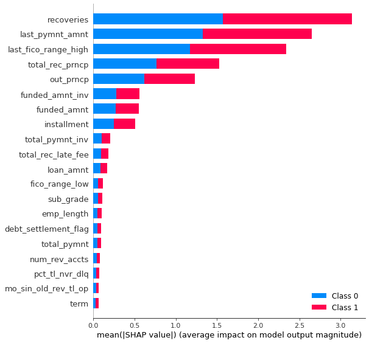

```python
import shap
shap_values = shap.TreeExplainer(clf).shap_values(df_sample)
shap.summary_plot(shap_values, X_train, plot_type="bar")
```

### 추가 변수 조정

- 4가지 변수선택법(ANOVA, Chi-Squared Test, ML Model, SHAP)에서 공통으로 유의한 변수를 추출한다.
- 그 결과, 머신러닝 모델 기준으로 지나치게 높은 성능(AUC: 0.9914)을 보인다.
- 과도한 성능을 낮추고 더 적은 지표에도 안정적인 성능을 가지도록 특정 변수를 직접 제거 후 최종 독립변수를 선택한다.

기존 성능 지표 확인:

```python
y_pred=clf.predict(X_test)
print('LightGBM Model AUC score: {0:0.4f}'.format(roc_auc_score(y_test, y_pred)))
```

```
LightGBM Model AUC score: 0.9914
```

영향력이 높은 변수 확인:

[figure not shown]

```python
import matplotlib.pyplot as plt
import seaborn as sns

feature_imp = pd.DataFrame(sorted(zip(X.columns,clf.feature_importances_)), columns=['Feature','Value'])

plt.figure(figsize=(30, 20))
sns.barplot(x="Value", y="Feature", data=feature_imp.sort_values(by="Value", ascending=False))
plt.title('LightGBM Features')
plt.tight_layout()
plt.show()
```

총 58개 독립변수 선택:

```python
feat_imp = ["int_rate","dti","annual_inc","mo_sin_old_rev_tl_op","acc_open_past_24mths","loan_amnt","emp_length",
                    "revol_bal", "term", "funded_amnt_inv", "installment", "purpose",
                    "total_rev_hi_lim","fico_range_low","debt_settlement_flag", "mort_acc","total_bc_limit","home_ownership",
                    "avg_cur_bal","all_util","mths_since_recent_bc","total_acc","open_acc_6m","bc_util","num_actv_rev_tl",
                    "funded_amnt","hardship_flag","num_rev_tl_bal_gt_0","mths_since_recent_inq","inq_last_6mths", "num_il_tl",
                    "mo_sin_old_il_acct","num_rev_accts","num_tl_120dpd_2m","total_il_high_credit_limit","application_type",
                    "revol_util","tot_hi_cred_lim","delinq_2yrs","mo_sin_rcnt_tl","num_actv_bc_tl","mths_since_last_record",
                    "percent_bc_gt_75", "bc_open_to_buy","max_bal_bc","grade","open_rv_24m","mo_sin_rcnt_rev_tl_op",
                    "pct_tl_nvr_dlq","verification_status","tot_cur_bal","total_bal_ex_mort","mths_since_last_major_derog",
                    "inq_fi","mths_since_rcnt_il","inq_last_12m","mths_since_last_delinq","num_bc_tl"]
```

LightGBM 모델 재학습:

```python
X,y = df[feat_imp], df[TARGET]
X_train, X_test, y_train, y_test = train_test_split(X, y, test_size = 0.3, random_state = 0)

clf = lgb.LGBMClassifier()
clf.fit(X_train, y_train)
```

```
LGBMClassifier()
```

낮춘 모델 성능 지표 확인:

```python
y_pred=clf.predict(X_test)
print('LightGBM Model AUC score: {0:0.4f}'.format(roc_auc_score(y_test, y_pred)))
```

```
LightGBM Model AUC score: 0.5897
```

최종 데이터셋(ID, 58개 독립변수, 종속변수, 날짜변수) 저장:

```python
feat_imp += ['loan_status','issue_d','id']
df[feat_imp].to_pickle('../Data/feature_selected.pkl')
```